# Time Series Analysis Using Max/Min… and some Neuroscience.

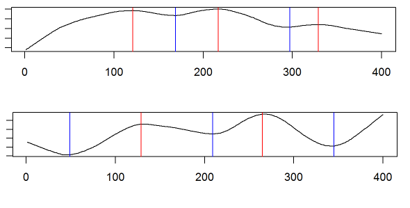

*Originally posted at: blog.datascienceheroes.com*

### Introduction

Time series has **maximum** and **minimum** points as general patterns. Sometimes the noise present on it causes problems to spot general behavior.

In this post, we will **smooth** time series -reducing noise- to maximize the story that data has to tell us. And then, an easy formula will be applied to find and plot max/min points thus characterize data.

### What we have

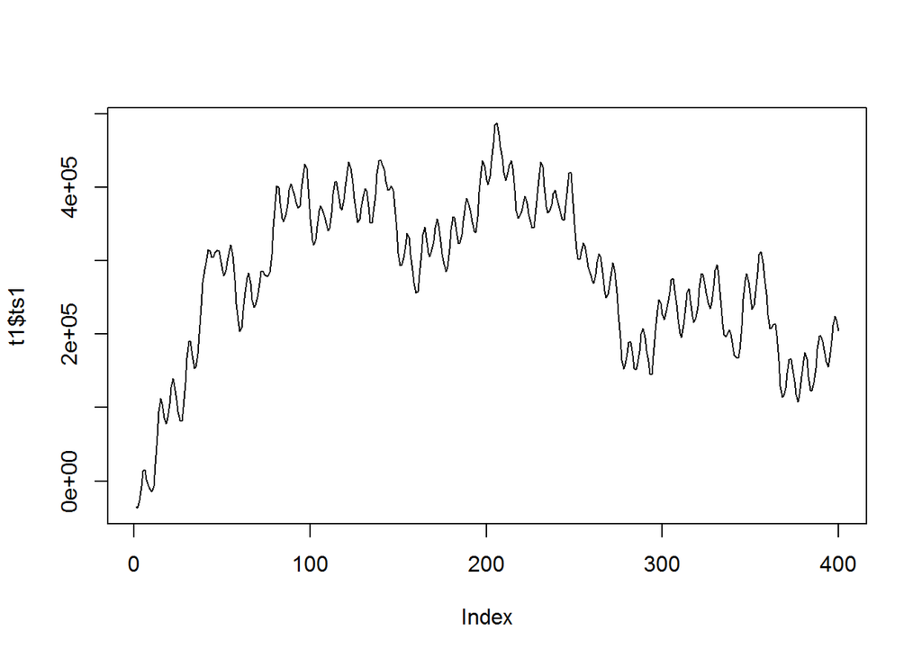

```r
# reading data sources, 2 time series
t1=read.csv("ts_1.txt")
t2=read.csv("ts_2.txt")


# plotting...
plot(t1$ts1, type = 'l')
```

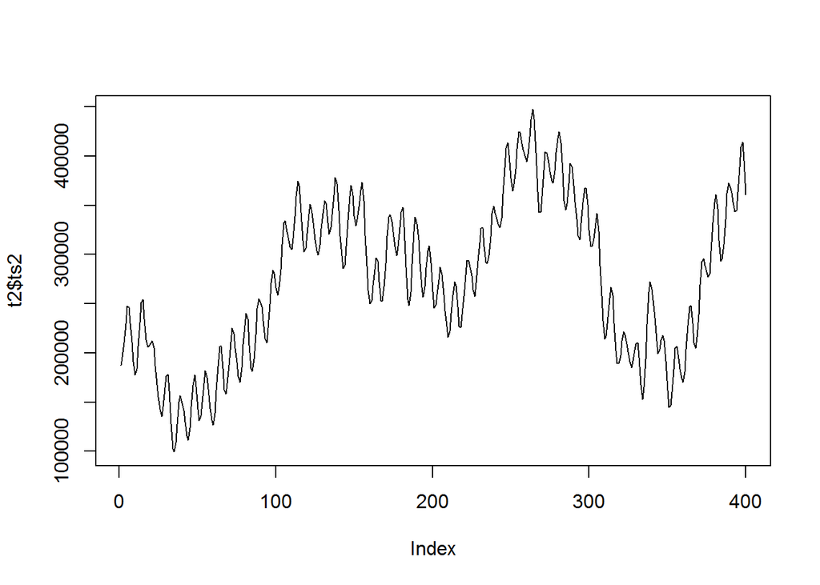

```r
plot(t2$ts2, type = 'l')
```

As you can see there are many peaks, but intuitively you can imagine a more smoother line crossing in the middle of the points. This can achieved by applying a **Seasonal Trend Decomposition** (STL).

### Smoothing the series

```r
# first create the time series object, with frequency = 50, and then apply the stl function.
stl_1=stl(ts(t1$ts1, frequency=50), "periodic")
stl_2=stl(ts(t2$ts2, frequency=50), "periodic")
```

*Important*: If you don’t know the `frequency` beforehand, play a little bit with this parameter until you find a result in which you are comfortable.

[More STL info](https://anomaly.io/seasonal-trend-decomposition-in-r)

### Finding max and min

Creating the functions…

```r
ts_max<-function(signal)
{
  points_max=which(diff(sign(diff(signal)))==-2)+1
  return(points_max)
}

ts_min<-function(signal)
{
  points_min=which(diff(sign(diff(-signal)))==-2)+1
  return(points_min)
}
```

### Visualizing the results!

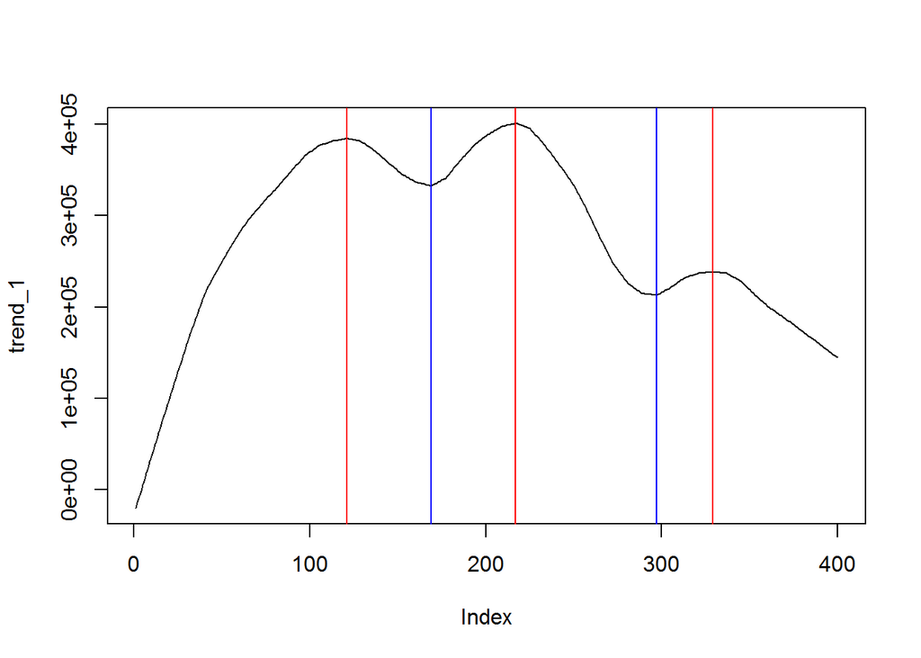

```r
trend_1=as.numeric(stl_1$time.series[,2])

max_1=ts_max(trend_1)
min_1=ts_min(trend_1)


## Plotting final results
plot(trend_1, type = 'l')
abline(v=max_1, col="red")
abline(v=min_1, col="blue")
```

With the line: `stl_1$time.series[,2]` we are accessing to the time series `trend` component. This is the smoothing method we will use, but there are others.

This first series has 3 maximums *(red line)* and 2 minimum *(blue line)* in the following places:

```r
# When occurs the max points:
max_1
```

```
## [1] 121 217 329
```

```r
# When occurs the min points:
min_1
```

```
## [1] 169 297
```

### Comparing two time series

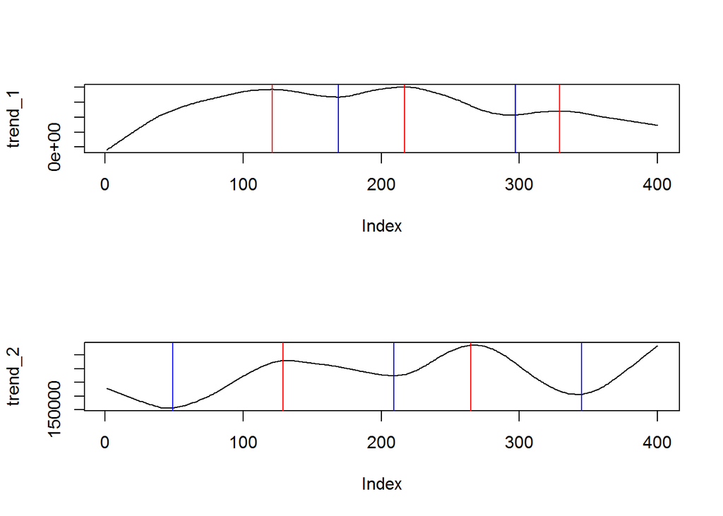

```r
trend_2=as.numeric(stl_2$time.series[,2])

max_2=ts_max(trend_2)
min_2=ts_min(trend_2)

# create two aligned plots
par(mfrow=c(2,1))

## Plotting series 1
plot(trend_1, type = 'l')
abline(v=max_1, col="red")
abline(v=min_1, col="blue")

## Plotting series 2
plot(trend_2, type = 'l')
abline(v=max_2, col="red")
abline(v=min_2, col="blue")
```

Some **conclusions** from both plots:

- Series 2 starts with a minimum while 1 does with a maximum
- Series 1 has 3 max and 2 min, just the opposite to the other series

Why is this important? Because of the data nature, which is in next section.

### What is this data about?

`ts1` and `ts2` are two typical responses to a brain stimulus, in other words: what happen with the brain when a person look at a picture / move a finger / think in a particular thing, etc… Electroencephalography.

Some studies in **neuroscience** focus on averaging several responses to one stimulus -for example, to look at one particular picture. They present several times a particular image to the person. Averaging all of these signal/time series, you get the **typical response**.

Then you can **predict** based on the similarity between this **typical response** and the **new image** (stimulus) that the person is looking at.

#### Typical response (or Event Related Potential)

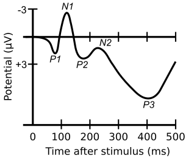

Important to get the **when** positive (`P1`, `P2` and `P3`) peaks occurs. The same goes for the negative ones.

[Wiki: Event related potential](https://en.wikipedia.org/wiki/Event-related_potential).

*Note: It´s a common practise to invert negative and positive values.*

#### Finally…

Typically the signal time length for this kind of studies last for **400ms**, thus 1 point per millisecond, just the displayed plots. And the amplitude is in **volts**, *(actually micro-volts)*. The same unit of measurement used by the notebook you are using now ;)

[figure not shown]